# Exploring the Relationship Between Transmission Type and Fuel Efficiency

Success Moses(msucc2024@gmail.com)

2024-09-02

### Summary

This analysis explores the relationship between transmission type and fuel efficiency (measured in miles per gallon, MPG). Variables from the `mtcars` dataset were selected through exploratory data analysis for inclusion in a linear regression model. Residual analysis revealed a non-linear relationship between the outcome (MPG) and the predictor variables, leading to the inclusion of quadratic terms in the final model.

The coefficient of the dummy variable for transmission type (am) represents the difference in expected MPG between manual and automatic transmission vehicles. The confidence interval for this coefficient includes zero, indicating that **there is no significant difference in MPG between vehicles with automatic and manual transmissions**.

### Exploratory Data Analysis

The dataset being used is the built-in mtcars dataset from R, which contains information about various car models, including miles per gallon (mpg) and transmission type (am). Below are the list of features in the dataset.

```r
library(ggplot2)
paste(names(mtcars), collapse = ' ||  ')
```

```
[1] "mpg ||  cyl ||  disp ||  hp ||  drat ||  wt ||  qsec ||  vs ||  am ||  gear ||  carb"
```

```r
dim(mtcars)
```

```
[1] 32 11
```

### Boxplot of MPG by Transmission Type

The following boxplot visualizes the distribution of miles per gallon for cars with automatic and manual transmissions:

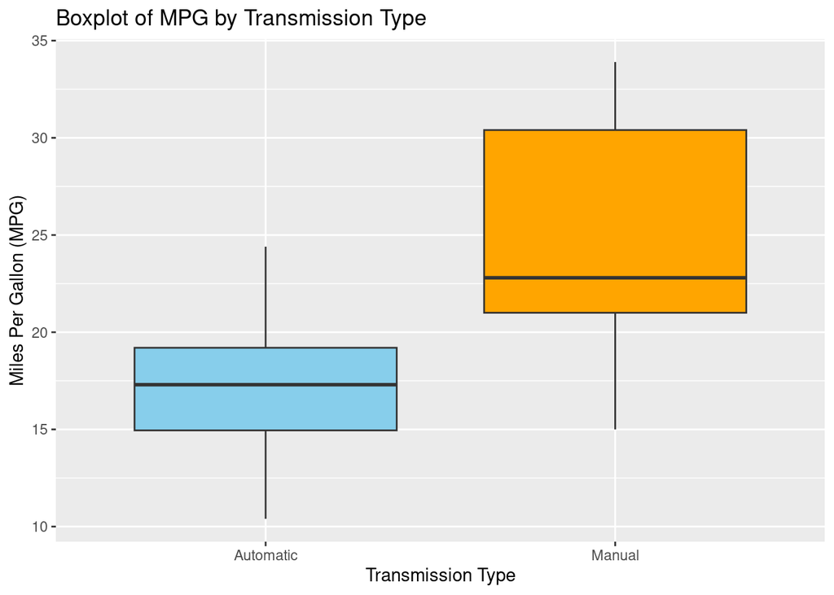

```r
# Convert 'am' to a factor variable for better labeling
mtcars$am <- factor(mtcars$am, labels = c('Automatic', 'Manual'))

# Create a boxplot of mpg by transmission type (am)
ggplot(mtcars, aes(x = am, y = mpg)) +
  geom_boxplot(fill = c("skyblue", "orange")) +
  labs(
    title = "Boxplot of MPG by Transmission Type",
    x = "Transmission Type",
    y = "Miles Per Gallon (MPG)"
  )
```

The boxplot shows that cars with manual transmissions generally have higher miles per gallon (MPG) compared to those with automatic transmissions.

### Hypothesis Test: Comparing Mean MPG between Transmission Types

To formally test whether the observed difference in MPG between automatic and manual transmissions is statistically significant, a t-test is performed:

```r
# Perform t-test to compare the means of MPG between transmission types
t_test_result <- t.test(mpg ~ am, data = mtcars)

# Display the t-test results
t_test_result
```

```
    Welch Two Sample t-test

data:  mpg by am
t = -3.7671, df = 18.332, p-value = 0.001374
alternative hypothesis: true difference in means between group Automatic and group Manual is not equal to 0
95 percent confidence interval:
 -11.280194  -3.209684
sample estimates:
mean in group Automatic    mean in group Manual
               17.14737                24.39231
```

The t-test results show that the observed difference in MPG is statistically significant with a p-value of `0.0013736`. However, the effect of transmission type may be influenced by other variables, so it is important to account for them in a multivariable model.

### Correlation Analysis

To identify other variables that may influence the relationship between transmission type and MPG, the following code calculates the correlation between transmission type (`am`) and all other variables in the dataset:

```r
coef = sapply(names(mtcars), function(name) {
  cor(as.numeric(mtcars[, name]), as.numeric(mtcars[, 'am']))
})

names(coef[abs(coef) > 0.5])
```

```
[1] "mpg"  "cyl"  "disp" "drat" "wt"   "am"   "gear"
```

```r
names(coef[abs(coef) > 0.7])
```

```
[1] "drat" "am"   "gear"
```

The output shows the names of variables that have a significant correlation (absolute value of correlation > 0.5 and > 0.7) with the transmission type.

### Model Selection Using ANOVA

Several models are fit using variables that are correlated with transmission type, and an Analysis of Variance (ANOVA) is used to compare them:

```r
model1 <- lm(mpg ~ ., mtcars)
model2 <- lm(mpg ~ am + wt + drat + disp + gear + cyl, mtcars)
model3 <- lm(mpg ~ drat + wt + am + gear, mtcars)

anova(model3, model2, model1)
```

```
Analysis of Variance Table

Model 1: mpg ~ drat + wt + am + gear
Model 2: mpg ~ am + wt + drat + disp + gear + cyl
Model 3: mpg ~ cyl + disp + hp + drat + wt + qsec + vs + am + gear + carb
  Res.Df    RSS Df Sum of Sq      F  Pr(>F)
1     27 260.41
2     25 182.10  2    78.305 5.5745 0.01143 *
3     21 147.49  4    34.606 1.2318 0.32759
---
Signif. codes:  0 '***' 0.001 '**' 0.01 '*' 0.05 '.' 0.1 ' ' 1
```

Model 2 appears to be the best fit, with a p-value of `0.01143`, while model 3 is not significant. Thus, model 2 is selected for further analysis.

### Residuals vs Fitted Values Plot

The following plot shows the residuals vs fitted values for model 2. Any significant bias would indicate a non-linear relationship between the predictors and the outcome:

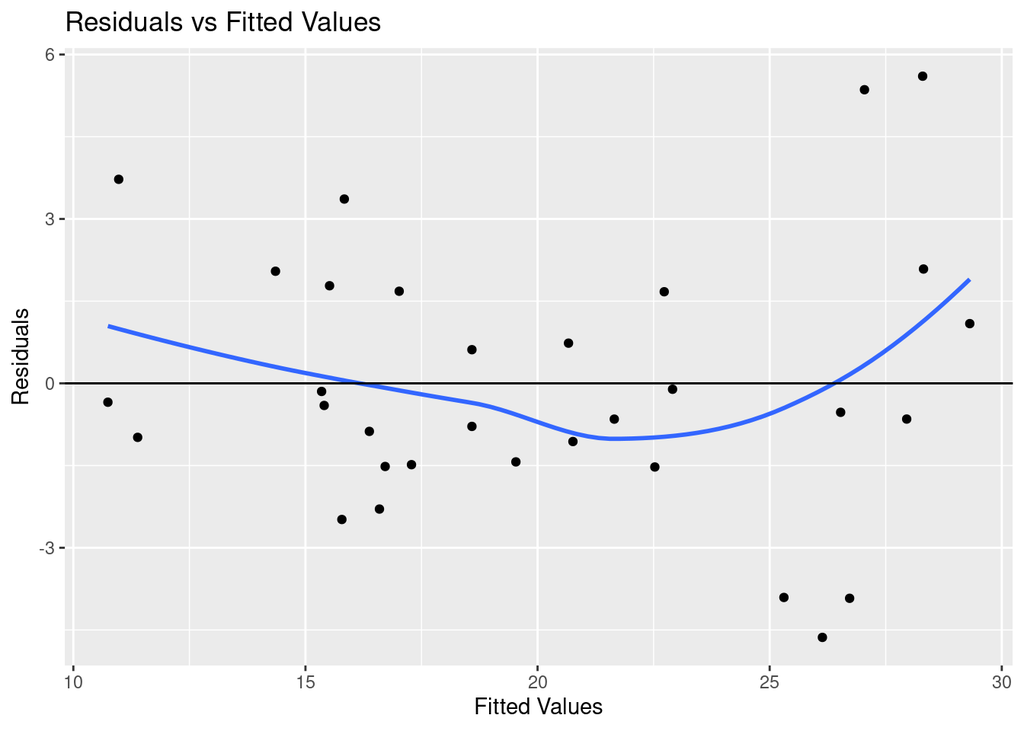

```r
fit <- predict(model2)
res <- resid(model2)

ggplot(mapping = aes(fit, res)) +
  geom_point() + geom_smooth(span = 1, se = FALSE) + geom_hline(yintercept = 0) +
  labs(title = "Residuals vs Fitted Values", x = "Fitted Values", y = "Residuals")
```

The plot indicates some non-linearity, suggesting that quadratic terms may need to be included in the model.

### Final Model and Conclusion

A final model is fit including quadratic terms for some of the predictors to account for the non-linear relationship:

```r
model4 <- lm(
  mpg ~ am + wt + drat + disp + cyl + gear + I(wt^2) + I(drat^2) + I(disp^2),
  mtcars
)

# Display the confidence interval for the coefficient of 'am'
confint(model4)['amManual', ]
```

```
    2.5 %    97.5 %
-5.794009  2.987719
```

The confidence interval for the coefficient of the dummy variable for manual transmission includes zero, there is insufficient evidence for a difference in mpg across transmission type. By accounting for other variables that may confound the relationship between `am` and `mpg`, the conclusion is that **there is no statistically significant difference in MPG between cars with automatic and manual transmissions**.